# Lab 03

### 0.1.5 Caso de estudio

#### 0.1.5.1 Datos de salmones en el Pacífico norte

Vamos a implementar algunas regresiones lineales, donde la variable respuesta es la productividad de un stock de salmón y las variables independientes son la biomasa de desovantes y temperatura.

```r
# Iniciamos con datos aplicados:
chum = read.csv('data/coastwide_chum_data.csv')

# Elegir solo los datos que necesitamos:
stock1 = chum[chum$stock=='SE-SC AKPen',c('stock','entry.yr','spawners','recruits','ln.rs',
                                         'loc.sst','w.sst.1','w.sst.2','npgo2','npgo','pdo2','pdo','long','lat')]
head(stock1)
```

```
##           stock entry.yr spawners recruits       ln.rs     loc.sst    w.sst.1
## 764 SE-SC AKPen     1963   238600   576200  0.88166631  0.04182643 -0.2207373
## 765 SE-SC AKPen     1964   263000   251500 -0.04471104 -1.19076329  0.6549483
## 766 SE-SC AKPen     1965   160800   313100  0.66636127 -0.47777858  1.0118060
## 767 SE-SC AKPen     1966   203300   192000 -0.05718735 -1.02832160 -1.1020202
## 768 SE-SC AKPen     1967   354800   657883  0.61747285  0.59927106 -0.3414790
## 769 SE-SC AKPen     1968   132800   846192  1.85190205  0.20264870 -0.5955610
##         w.sst.2        npgo2       npgo   pdo2    pdo long  lat
## 764  0.21710551  0.164053783 -0.2557230 -0.659 -0.472  161 55.5
## 765  0.83337719 -0.007529911  0.5838306 -0.891 -0.846  161 55.5
## 766 -0.04510709 -0.714296310 -0.5988904 -0.735 -0.936  161 55.5
## 767 -0.72174962 -0.809721169 -0.8297022 -0.572 -0.534  161 55.5
## 768 -0.46852000 -0.679363840 -0.7897401 -0.516 -0.610  161 55.5
## 769 -0.32856791 -0.796891715 -0.5689875 -0.653 -0.422  161 55.5
```

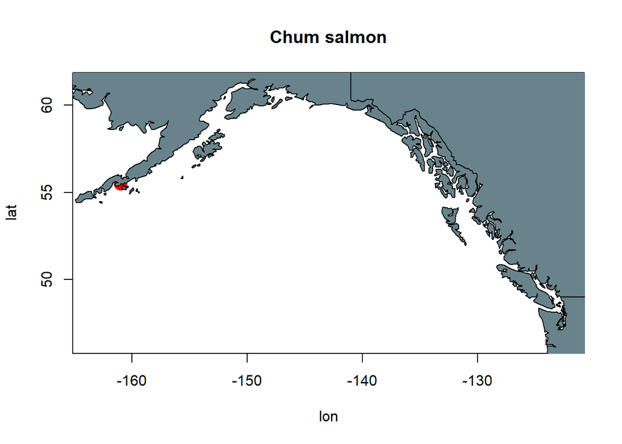

```r
# Exploremos que datos tenemos en el mapa:
plot(-stock1$long,stock1$lat,
     ylab='lat',
     xlab='lon',
     ylim=range(chum$lat),
     xlim=range(-chum$long),
     pch=16,main='Chum salmon',col='red',cex=2)
map("world", fill=T, col="lightblue4", add=T)
```

```r
# Vamos a implementar muchos modelos lineales:
# La variable Y sera ln.rs (indicador de productividad)
lm_0 = lm(ln.rs ~ spawners, data=stock1)
lm_pdo = lm(ln.rs ~ spawners + pdo, data=stock1)
lm_loc_sst = lm(ln.rs ~ spawners + loc.sst, data=stock1)

# Hagamos resumen de algunos modelos
summary(lm_0)
```

```
##
## Call:
## lm(formula = ln.rs ~ spawners, data = stock1)
##
## Residuals:
##      Min       1Q   Median       3Q      Max
## -1.08398 -0.26782  0.08663  0.29962  0.76672
##
## Coefficients:
##               Estimate Std. Error t value Pr(>|t|)
## (Intercept)  1.387e+00  1.675e-01   8.279 1.61e-10 ***
## spawners    -1.771e-06  5.332e-07  -3.322  0.00181 **
## ---
## Signif. codes:  0 '***' 0.001 '**' 0.01 '*' 0.05 '.' 0.1 ' ' 1
##
## Residual standard error: 0.4526 on 44 degrees of freedom
## Multiple R-squared:  0.2005, Adjusted R-squared:  0.1823
## F-statistic: 11.03 on 1 and 44 DF,  p-value: 0.001807
```

```r
summary(lm_pdo)
```

```
##
## Call:
## lm(formula = ln.rs ~ spawners + pdo, data = stock1)
##
## Residuals:
##      Min       1Q   Median       3Q      Max
## -0.99847 -0.24559 -0.01344  0.25640  0.77313
##
## Coefficients:
##               Estimate Std. Error t value Pr(>|t|)
## (Intercept)  1.514e+00  1.543e-01   9.813 1.53e-12 ***
## spawners    -2.202e-06  4.929e-07  -4.467 5.67e-05 ***
## pdo          2.341e-01  6.762e-02   3.462  0.00122 **
## ---
## Signif. codes:  0 '***' 0.001 '**' 0.01 '*' 0.05 '.' 0.1 ' ' 1
##
## Residual standard error: 0.4048 on 43 degrees of freedom
## Multiple R-squared:  0.3748, Adjusted R-squared:  0.3457
## F-statistic: 12.89 on 2 and 43 DF,  p-value: 4.117e-05
```

```r
summary(lm_loc_sst)
```

```
##
## Call:
## lm(formula = ln.rs ~ spawners + loc.sst, data = stock1)
##
## Residuals:
##      Min       1Q   Median       3Q      Max
## -0.87700 -0.27362  0.05539  0.21381  0.68280
##
## Coefficients:
##               Estimate Std. Error t value Pr(>|t|)
## (Intercept)  1.534e+00  1.531e-01  10.021 8.11e-13 ***
## spawners    -2.273e-06  4.897e-07  -4.641 3.25e-05 ***
## loc.sst      2.456e-01  6.675e-02   3.680 0.000646 ***
## ---
## Signif. codes:  0 '***' 0.001 '**' 0.01 '*' 0.05 '.' 0.1 ' ' 1
##
## Residual standard error: 0.3992 on 43 degrees of freedom
## Multiple R-squared:  0.3919, Adjusted R-squared:  0.3637
## F-statistic: 13.86 on 2 and 43 DF,  p-value: 2.264e-05
```

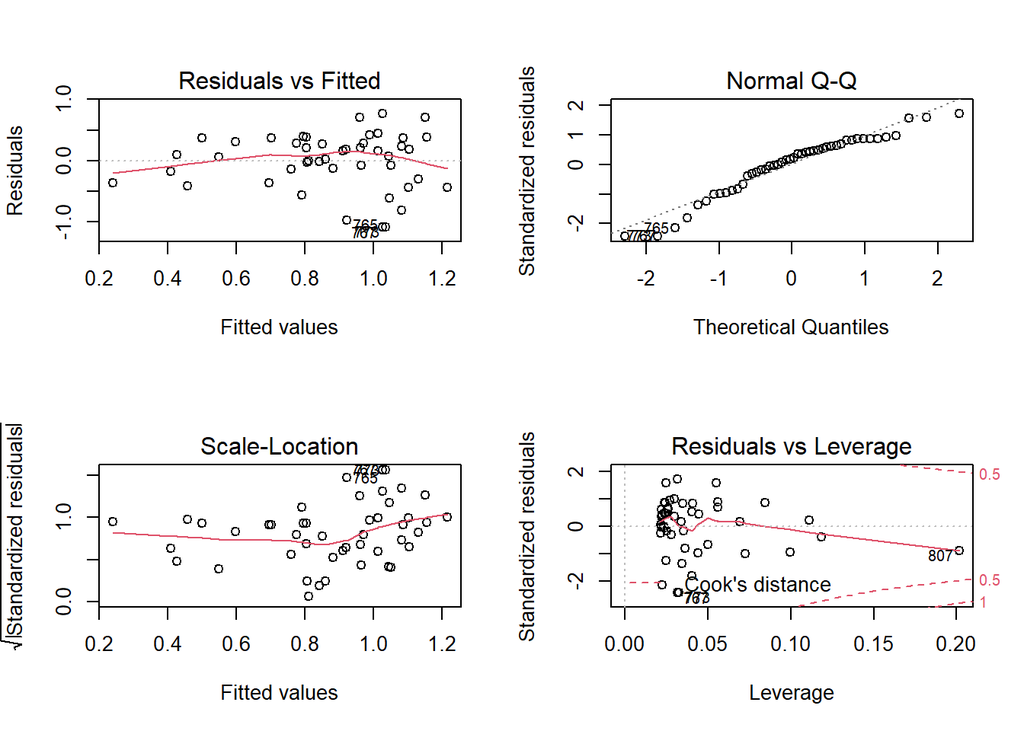

```r
# Observemos algunas figuras para analizar las asunciones de este metodo
opar = par(mfrow=c(2,2)) # panel 2 por 2
plot(lm_0)
```

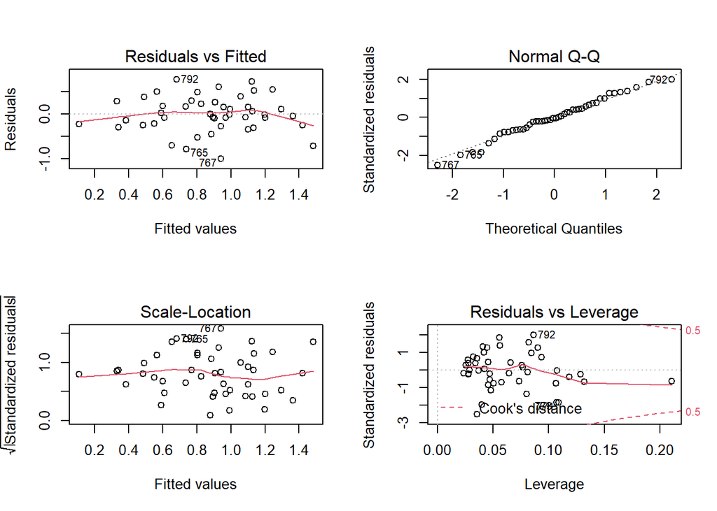

```r
plot(lm_pdo)
```

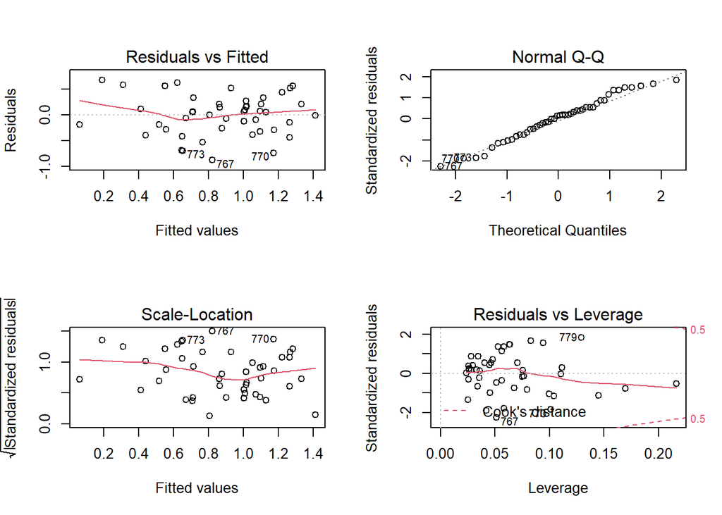

```r
plot(lm_loc_sst)
```

```r
par(opar) # vuelve a la configuracion de plot inicial

# Podemos utilizar un indicador para comparar modelos:
AIC(lm_0, lm_pdo, lm_loc_sst) # elegimos el valor mas bajo
```

```
##            df      AIC
## lm_0        3 61.55952
## lm_pdo      4 52.24755
## lm_loc_sst  4 50.96795
```

#### 0.1.5.2 Datos de dieta de aves

Vamos a implementar una regresión lineal donde tendremos que tranformar la variable para que los supuestos se cumplan.

```r
# Leemos los datos:
bird = read.csv("data/birdsdiet.csv")
head(bird)
```

```
##               Family   MaxAbund   AvgAbund       Mass        Diet Passerine
## 1 Hawks&Eagles&Kites   2.985544  0.6740216  716.01894  Vertebrate         0
## 2   Long-tailed tits  37.800000  4.0404300    5.30000      Insect         1
## 3              Larks 241.400000 23.1054000   35.77709 PlantInsect         1
## 4        Kingfishers   4.400000  0.5949060  119.37172  Vertebrate         0
## 5      Auks& Puffins   4.532505  2.9632718  315.49552  InsectVert         0
## 6       Ducks& Geese  23.693635  2.7416729 1144.29003 PlantInsect         0
##   Aquatic
## 1       0
## 2       0
## 3       0
## 4       0
## 5       1
## 6       1
```

```r
# Resumen rapido de mi base de datos
summary(bird)
```

```
##     Family             MaxAbund          AvgAbund           Mass
##  Length:54          Min.   :  0.200   Min.   : 0.200   Min.   :   5.30
##  Class :character   1st Qu.:  5.402   1st Qu.: 1.340   1st Qu.:  20.68
##  Mode  :character   Median : 24.147   Median : 3.114   Median :  59.18
##                     Mean   : 44.906   Mean   : 5.686   Mean   : 468.48
##                     3rd Qu.: 43.581   3rd Qu.: 6.258   3rd Qu.: 461.73
##                     Max.   :413.600   Max.   :47.598   Max.   :5296.23
##      Diet             Passerine        Aquatic
##  Length:54          Min.   :0.000   Min.   :0.0000
##  Class :character   1st Qu.:0.000   1st Qu.:0.0000
##  Mode  :character   Median :0.000   Median :0.0000
##                     Mean   :0.463   Mean   :0.2778
##                     3rd Qu.:1.000   3rd Qu.:1.0000
##                     Max.   :1.000   Max.   :1.0000
```

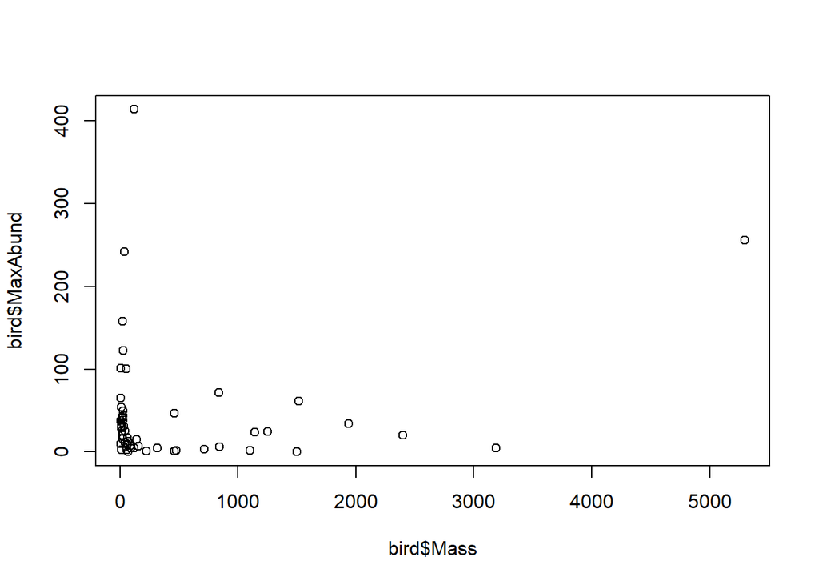

```r
# Exploremos las variables que queremos modelar:
plot(bird$Mass, bird$MaxAbund)
```

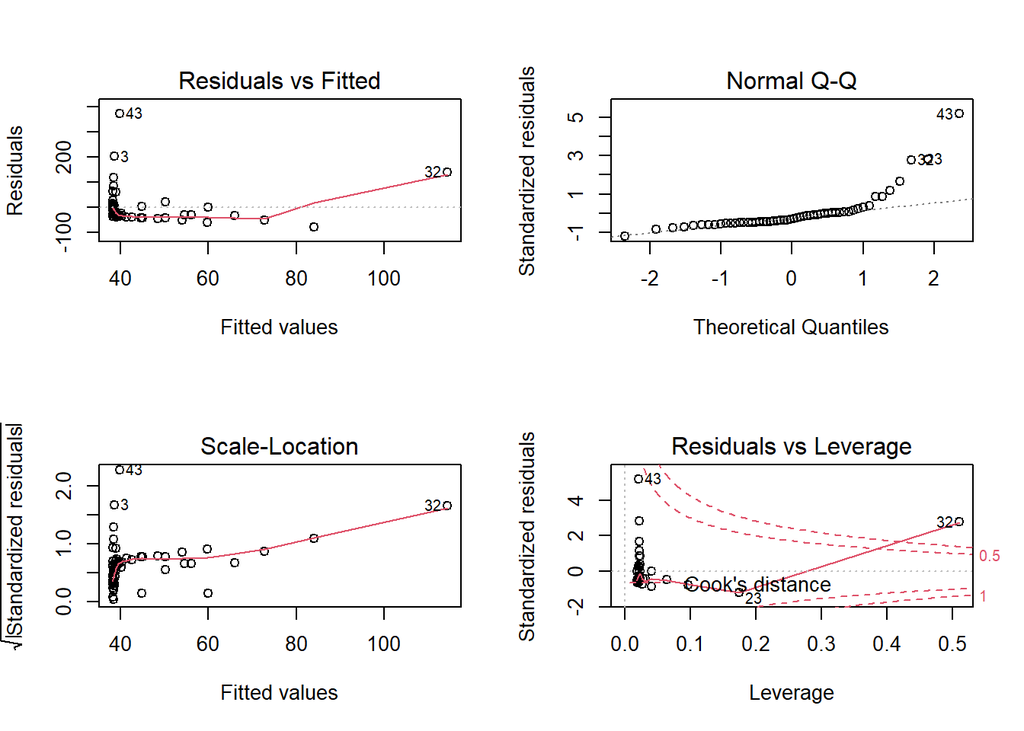

```r
# Implementamos el modelo (regresion) linear:
lm1 = lm(bird$MaxAbund ~ bird$Mass)

# Exploremos los resultados
opar = par(mfrow=c(2,2))
plot(lm1)
```

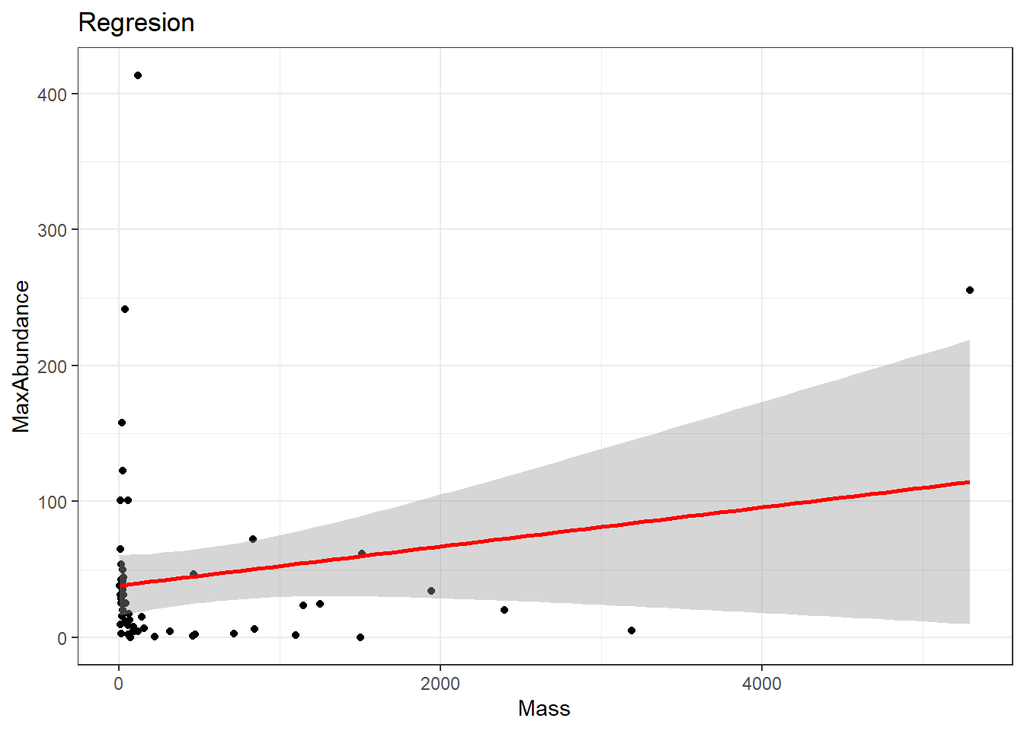

```r
par(opar)

# Plot Y ~ X y la linea de regresion:
ggplot(bird, aes(x = Mass,y = MaxAbund))+
  geom_point()+
  geom_smooth(method="lm", colour = 'red') +
  ylab('MaxAbundance') +
  xlab('Mass') +
  ggtitle('Regresion') +
  theme_bw()
```

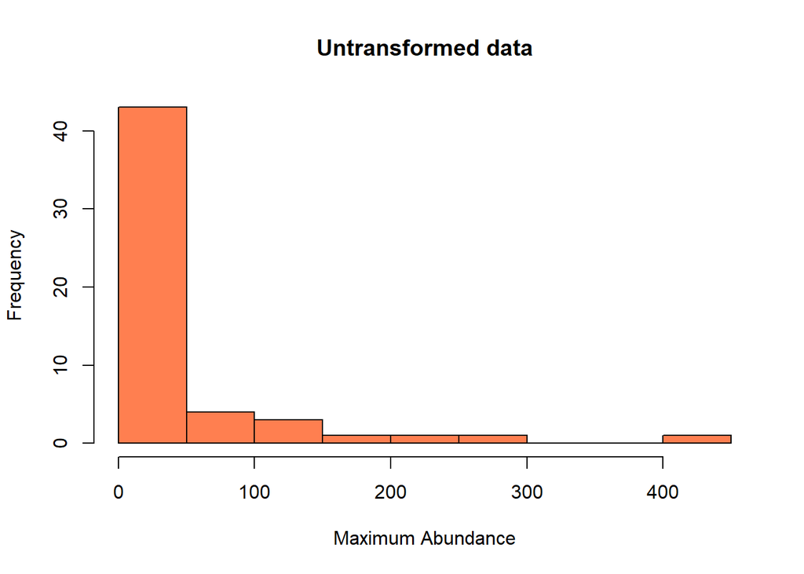

```r
# Veamos si los datos estan normalmente distribuidos
hist(bird$MaxAbund,col="coral", main="Untransformed data",
     xlab="Maximum Abundance")
```

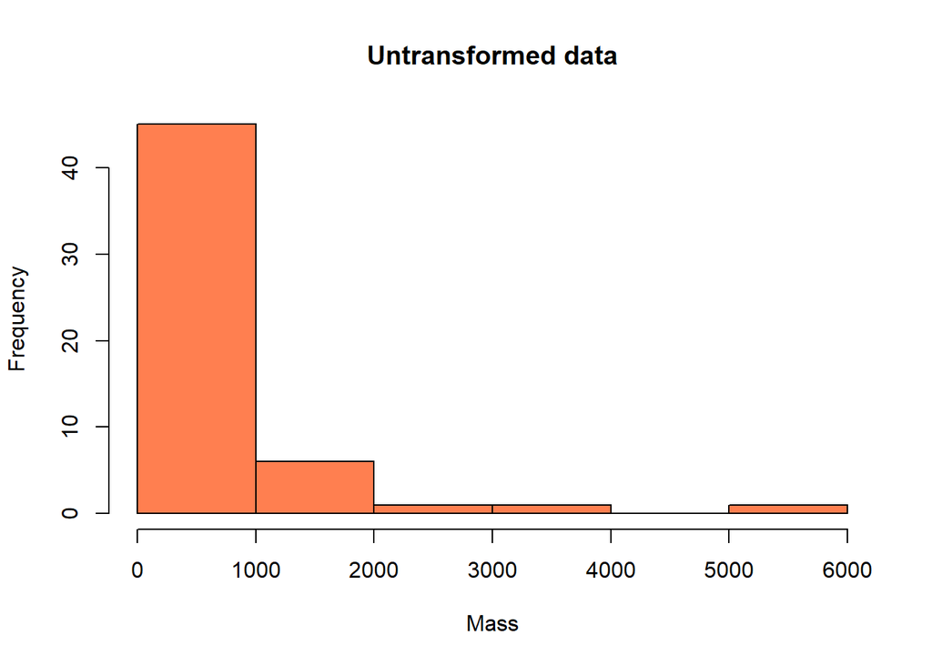

```r
hist(bird$Mass, col="coral", main="Untransformed data", xlab="Mass")
```

```r
# Podemos correr una prueba de hipotesis para saber si
# los datos vienen de una distribucion normal
# H0: la distribucion es normal
shapiro.test(bird$MaxAbund)
```

```
##
##  Shapiro-Wilk normality test
##
## data:  bird$MaxAbund
## W = 0.5831, p-value = 3.872e-11
```

```r
shapiro.test(bird$Mass)
```

```
##
##  Shapiro-Wilk normality test
##
## data:  bird$Mass
## W = 0.54667, p-value = 1.155e-11
```

```r
# Si p < 0.05, la distribucion NO es normal
# Si p > 0.05, la distribucion es normal

# Podemos analizar tambien la simetria de mis datos
skewness(bird$MaxAbund)
```

```
## [1] 3.257217
```

```r
skewness(bird$Mass)
```

```
## [1] 3.23552
```

```r
# datos positivos: distribucion hacia la izquiera
# datos negativos: distribucion hacia la derecha

# Vamos a transformar mis datos con log (logaritmo natural)
bird$logMaxAbund = log(bird$MaxAbund)
bird$logMass = log(bird$Mass)
names(bird)
```

```
## [1] "Family"      "MaxAbund"    "AvgAbund"    "Mass"        "Diet"
## [6] "Passerine"   "Aquatic"     "logMaxAbund" "logMass"
```

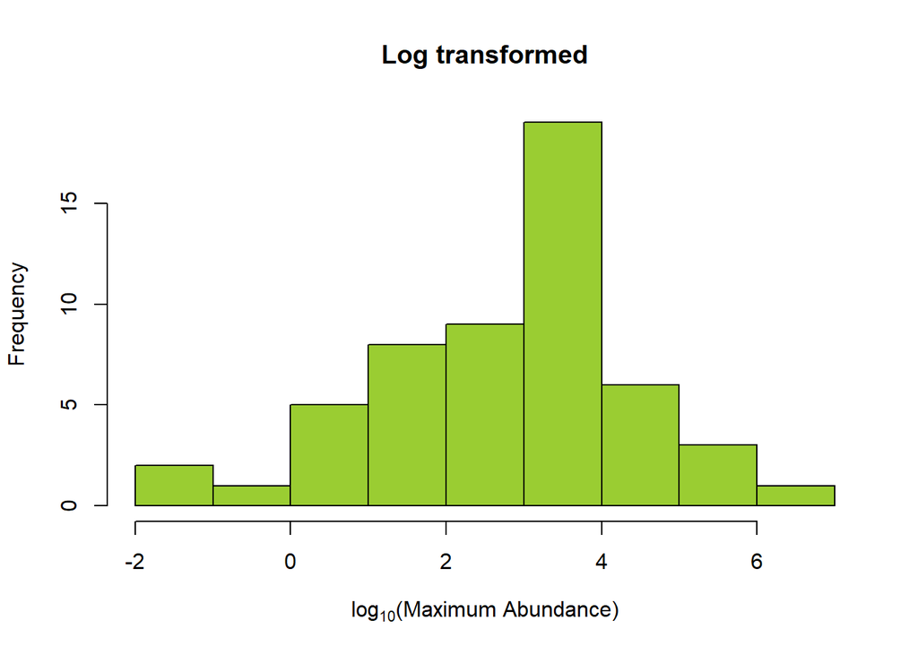

```r
# Veamos los nuevos datos:
hist(bird$logMaxAbund,col="yellowgreen", main="Log transformed",
     xlab=expression("log"[10]*"(Maximum Abundance)"))
```

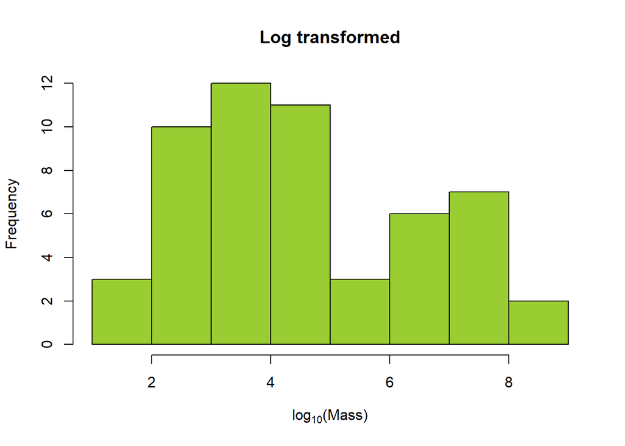

```r
hist(bird$logMass,col="yellowgreen", main="Log transformed",
     xlab=expression("log"[10]*"(Mass)"))
```

```r
# Correr nuevamente la prueba de hipotesis de normalidad y simetria:
shapiro.test(bird$logMaxAbund)
```

```
##
##  Shapiro-Wilk normality test
##
## data:  bird$logMaxAbund
## W = 0.96708, p-value = 0.1431
```

```r
skewness(bird$logMaxAbund)
```

```
## [1] -0.6089474
```

```r
shapiro.test(bird$logMass)
```

```
##
##  Shapiro-Wilk normality test
##
## data:  bird$logMass
## W = 0.93716, p-value = 0.007107
```

```r
skewness(bird$logMass)
```

```
## [1] 0.4768559
```

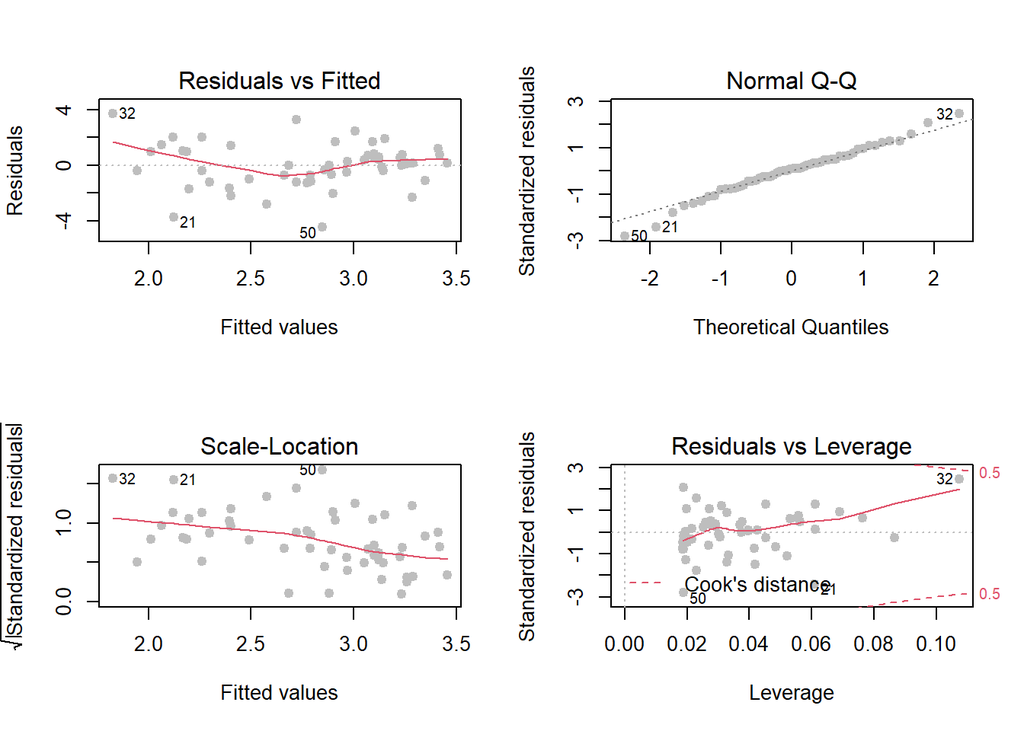

```r
# Corremos nuevamente el modelo:
lm2 = lm(bird$logMaxAbund ~ bird$logMass)

# Veamos las figuras para verificar las asunciones:
opar = par(mfrow=c(2,2))
plot(lm2, pch=19, col="gray")
```

```r
par(opar)

# Parece todo bien, ahora veamos los resultados del modelo:
summary(lm2)
```

```
##
## Call:
## lm(formula = bird$logMaxAbund ~ bird$logMass)
##
## Residuals:
##     Min      1Q  Median      3Q     Max
## -4.4569 -0.9206  0.1263  0.9354  3.7180
##
## Coefficients:
##              Estimate Std. Error t value Pr(>|t|)
## (Intercept)    3.8508     0.5691   6.767 1.17e-08 ***
## bird$logMass  -0.2361     0.1170  -2.019   0.0487 *
## ---
## Signif. codes:  0 '***' 0.001 '**' 0.01 '*' 0.05 '.' 0.1 ' ' 1
##
## Residual standard error: 1.602 on 52 degrees of freedom
## Multiple R-squared:  0.07267,    Adjusted R-squared:  0.05484
## F-statistic: 4.075 on 1 and 52 DF,  p-value: 0.04869
```

```r
# Podemos obtener informacion a partir de este objeto
summary(lm2)$coefficients
```

```
##                Estimate Std. Error   t value     Pr(>|t|)
## (Intercept)   3.8507680  0.5690882  6.766557 1.166186e-08
## bird$logMass -0.2361498  0.1169836 -2.018658 4.869342e-02
```

```r
summary(lm2)$r.squared
```

```
## [1] 0.07267022
```

```r
summary(lm2)$adj.r.squared
```

```
## [1] 0.05483696
```

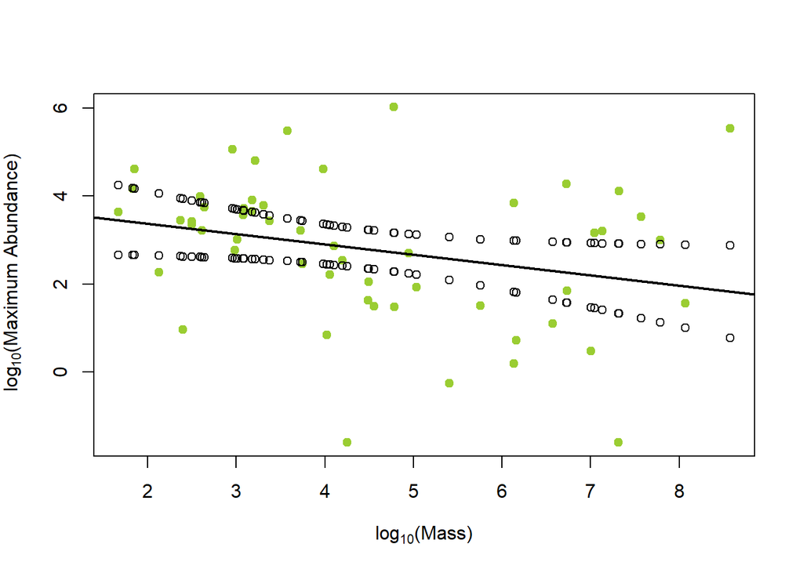

```r
# Ahora podemos graficar la regresion:
plot(logMaxAbund ~ logMass, data=bird, pch=19, col="yellowgreen",
     ylab = expression("log"[10]*"(Maximum Abundance)"), xlab = expression("log"[10]*"(Mass)"))
abline(lm2, lwd=2)
# Anadimos intervalos de confianza:
confit = predict(lm2, interval="confidence")
points(bird$logMass,confit[,2])
points(bird$logMass,confit[,3])
```

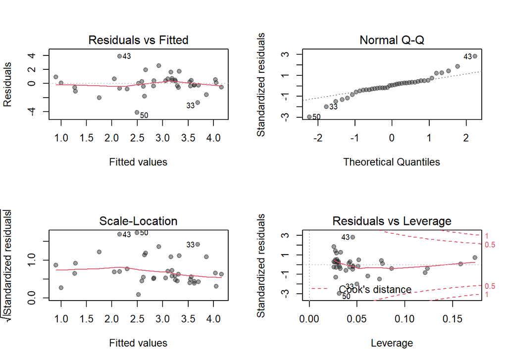

```r
# Podemos correr otro modelo excluyendo una parte de los datos:
lm3 = lm(logMaxAbund ~ logMass, data=bird, subset =! bird$Aquatic) # remover aves acuaticas

# Examine the model
opar = par(mfrow=c(2,2))
plot(lm3, pch=19, col=rgb(33,33,33,100,maxColorValue=225))
```

```r
summary(lm3)
```

```
##
## Call:
## lm(formula = logMaxAbund ~ logMass, data = bird, subset = !bird$Aquatic)
##
## Residuals:
##     Min      1Q  Median      3Q     Max
## -4.1053 -0.5327  0.0928  0.5280  3.8709
##
## Coefficients:
##             Estimate Std. Error t value Pr(>|t|)
## (Intercept)   5.2272     0.6750   7.744 2.96e-09 ***
## logMass      -0.6429     0.1746  -3.683 0.000733 ***
## ---
## Signif. codes:  0 '***' 0.001 '**' 0.01 '*' 0.05 '.' 0.1 ' ' 1
##
## Residual standard error: 1.403 on 37 degrees of freedom
## Multiple R-squared:  0.2682, Adjusted R-squared:  0.2485
## F-statistic: 13.56 on 1 and 37 DF,  p-value: 0.000733
```

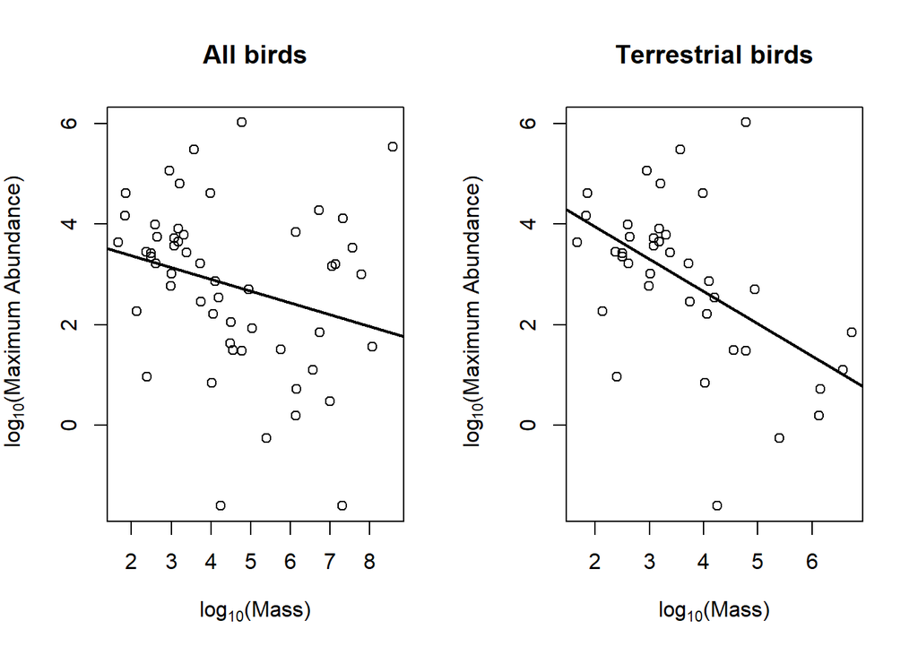

```r
par(opar)

# Comparamos ambas regresiones
opar = par(mfrow=c(1,2))
plot(logMaxAbund ~ logMass, data=bird, main="All birds", ylab = expression("log"[10]*"(Maximum Abundance)"),
     xlab = expression("log"[10]*"(Mass)"))
abline(lm2,lwd=2)

plot(logMaxAbund ~ logMass, data=bird, subset=!bird$Aquatic, main="Terrestrial birds",
     ylab = expression("log"[10]*"(Maximum Abundance)"), xlab = expression("log"[10]*"(Mass)"))
abline(lm3,lwd=2)
```

```r
par(opar)
```

## 0.2 Correlación

La covarianza entre dos variables ($X$ e $Y$) es una medida para cuantificar la relación entre ellas:

$Cov(X,Y) = E[(X-\mu_x)(Y-\mu_y)] = E[XY] - \mu_x\mu_y$

Si $X$ e $Y$ son independientes, entonces $Cov(X,Y) = 0$.

Coeficiente de correlación se calcula de la siguiente manera:

$\rho = Corr(X,Y) = \frac{Cov(X,Y)}{\sigma_X \sigma_Y}$

Este coeficiente de correlación no tiene dimensión (no tiene unidades) y toma valores entre -1 y 1. El coeficiente de correlación de Pearson es simplemente un estimado de $\rho$:

$r=\frac{L_{xy}}{\sqrt{L_{xx}L_{yy}}}$

Si $r$ toma valores cercanos a -1, decimos que hay una correlación negativa muy fuerte. Si toma valores cercanos a 1, decimos que hay una correlación positiva muy fuerte. Si $r$ toma valores cercanos a cero, decimos que las variables no están correlacionadas.

### 0.2.1 Prueba t

También se puede realizar una prueba t para observar la significancia de $r$ y sus intervalos de confianza. Aquí $H_0: \rho = 0$ y $H_A:\rho \neq 0$. El estadístico es:

$t=\frac{r(n-2)^{1/2}}{(1-r^2)^{1/2}}$

Para un nivel de significancia $\alpha$:

- Si $t>t_{n-2,1-\alpha /2}$ o $t<-t_{n-2,1-\alpha /2}$, entonces se rechaza $H_0$.
- Si $-t_{n-2,1-\alpha /2}<t<t_{n-2,1-\alpha /2}$, entonces fallamos en rechazar $H_0$

### 0.2.2 Correlación de rango (Rank correlation)

Este tipo de correlación se emplea para variables donde no se tiene seguro que siguen una distribución normal. El coeficiente de correlación de Spearman ($r_s$):

$r_s=\frac{L_{xy}}{\sqrt{L_{xx}L_{yy}}}$

Donde los $L$ son calculados a partir de los rangos en vez de los valores como lo hicimos anteriormente.

Vamos a ver algunas funciones para observar la correlación entre dos variables:

```r
# Prueba de hipotesis para correlacion:
cor.test(x, y)
```

```
##
##  Pearson's product-moment correlation
##
## data:  x and y
## t = 15.28, df = 98, p-value < 2.2e-16
## alternative hypothesis: true correlation is not equal to 0
## 95 percent confidence interval:
##  0.7697282 0.8891116
## sample estimates:
##       cor
## 0.8392598
```

```r
# Podriamos tambien correr la prueba para uun tipo Spearman
# Esto no asume normalidad
cor.test(x, y, method=c("spearman"))
```

```
##
##  Spearman's rank correlation rho
##
## data:  x and y
## S = 25024, p-value < 2.2e-16
## alternative hypothesis: true rho is not equal to 0
## sample estimates:
##      rho
## 0.849841
```

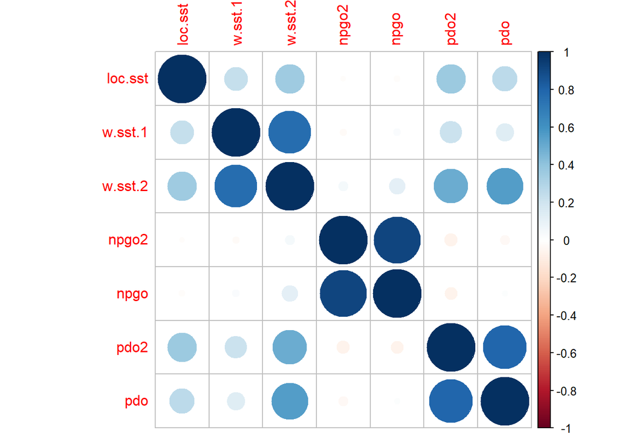

```r
# Ahora veamos un plot de correlacion entre variables ambientables
# tomados de la base de datos de salmon
# Hacemos un daata frame de solo variables ambientales:
envdata = chum[,c('loc.sst','w.sst.1','w.sst.2','npgo2','npgo','pdo2','pdo')]
corMat = cor(envdata)
corrplot(corMat, method="circle")
```

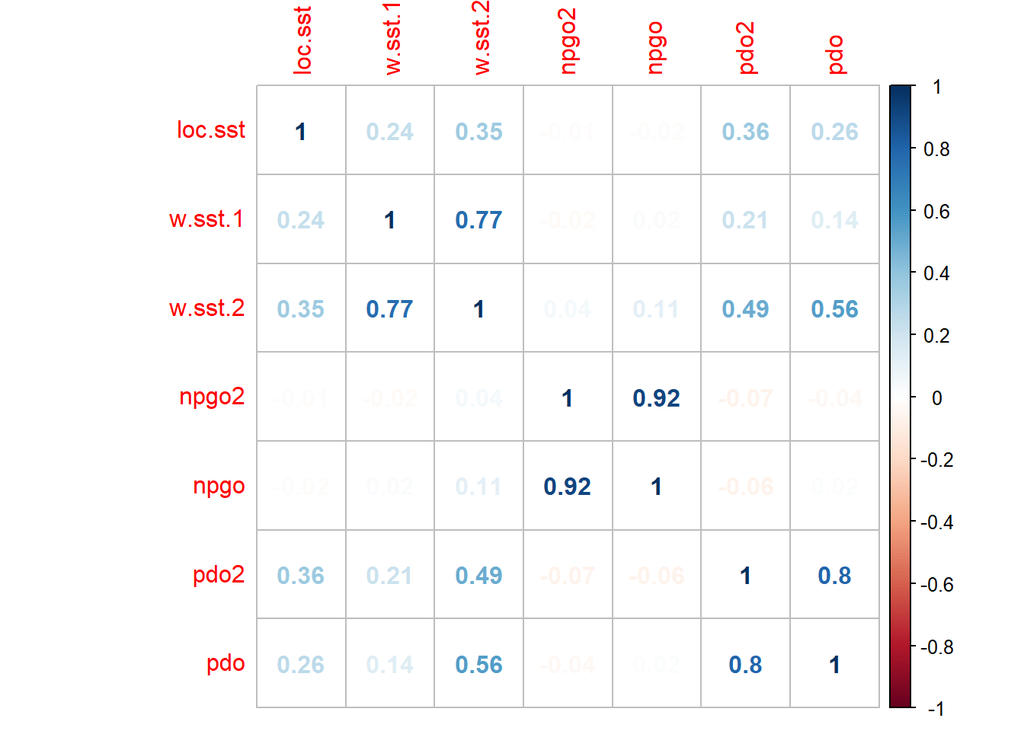

```r
corrplot(corMat, method="number")
```

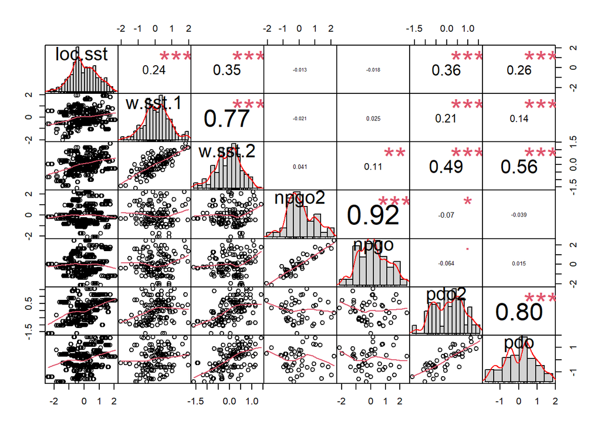

```r
chart.Correlation(envdata, histogram=TRUE, pch=19)
```

## 0.3 Transformación de una variable

Se utilizan transformaciones cuando la variable que queremos incluir en una regresión lineal no tiene una distribución cercana a la normal. Tenemos que tener cuidado para estos casos, ya que la interpretación de los parámetros estimados va a ser diferente. Tenemos los siguientes casos:

1. La variable dependiente es log-transformada: Para este caso, $(e^\beta - 1)100\%$ es el porcentaje de incremento (o reducción) en la variable respuesta por cada unidad de incremento en la variable independiente.
2. La variable independiente es log-transformada: El 1% de incremento en la variable independiente incrementa o reduce la variable dependiente en $\beta /100$ unidades.
3. Ambas variables son log-transformadas: $\beta$ es el incremento (o reducción) en porcentaje en la variable dependiente para cada 1% de incremento en la variable independiente.

## 0.4 Regresión múltiple

Para casos donde tenemos más de una variable independiente:

$y=\alpha + \sum_{j=1}^k \beta _jx_j+\epsilon$

Donde $\beta_j$ son conocidos como coeficientes de regresión parcial. Las variables independientes pueden ser continuas o categóricas. Para este caso, la interpretación de los coeficientes no cambia. Internamente, R asigna valores de 0, 1, 2, … a cada nivel de la variable categórica, y debemos tener presente qué categoría tiene cada número para poder hacer una interpretación adecuada.

Existen casos donde se especifica un efecto de interacción, por ejemplo:

$y=\alpha + \beta _1 x_{1,continua} + \beta _2 x_{2,categorica}+\beta _3 x_{1,continua}*x_{2,categorica}$

El símbolo $*$ significa un efecto de interacción. Para este caso, el efecto de $x_{1,continua}$ sobre $y$ va a ser diferente para distintos niveles de $x_{2,categorica}$. Por lo tanto, no solo tenemos que ver el valor de $\beta_1$, si no también el de $\beta_3$. Por ejemplo, el efecto de $x_{1,continua}$ sobre $y$ va a ser $\beta_1+\beta_3x_{2,categorica}$, luego reemplazamos $x_{2,categorica}$ por sus respectivos valores 0,1,2,.. y procedemos a obtener conclusiones.

Para estos casos, $\beta_2$ no tiene una interpretación lógica y se suelen ignorar.

En los ejercicios anteriores ya vemos visto algunos casos de regresión múltiple.

## 0.5 Validación de un modelo

En esta sección vamos a realizar un ejercicio simple de como validar un modelo mediante validación cruzada. Este método se basa en implementar un modelo estadístico (e.g. regresión lineal, modelo lineal generalizado, modelo aditivo generalizado, etc.) con un porcentaje de datos observados, y luego hacer predicciones usando las observaciones restastes, comparando los valores predichos con las observaciones de la variable respuesta.

```r
#Vamos a usar las variables simuladas anteriormente:
obs_data = data.frame(x=x, y=y)

#Seleccionamos 80 observaciones y reservamos 20 observaciones al azar:
n = 100 # numero de observaciones
ind = sample(c(TRUE, FALSE), n, replace=TRUE, prob=c(0.8, 0.2))
data1 = obs_data[ind, ]
data2 = obs_data[!ind, ]

# Construimos la regresion con el 80%
lm1 = lm(y~x, data = data1)

# Predecimos valores usando las observaciones del 20% reservado
pred_data = predict(lm1, newdata = data.frame(x = data2$x), interval = 'predict')

# Encontramos la correlacion entre lo predicho y observado en el 20% reservado:
# Debe estar muy cercano a 1:
cor(pred_data[,1], data2$y)
```

```
## [1] 0.9305692
```

```r
# Estos pasos se deben hacer muchas veces (iteraciones). La correlacion debe estar
# cercana a 1 para que el modelo sea robusto.
```